# Electric Vehicles and Cryptocurrency Analyses

Afrin F Razvi

# 1. Net Present Value (NPV) for EV Investment

In this section, I analyse a five-year investment in battery-powered electric vehicles (EVs) using Net Present Value (NPV). The aim is to understand whether the projected cashflows generate sufficient value at different discount rates.

## 1.1 Cashflow table

```r
cashflows <- build_cashflows()
cashflows
```

```
##   year outflow inflow
## 1 2023      20      0
## 2 2024      15      0
## 3 2025      15     10
## 4 2026      10     20
## 5 2027      10     25
## 6 2028       5     30
```

The table summarises the expected inflows and outflows from 2023 to 2028. All values are in billions of pounds.

## 1.2 NPV at a 3% discount rate

```r
result_3pct <- analyse_cashflow(cashflows, rate = 0.03)
result_3pct$cashflows
```

```
##   year outflow inflow return n       pvf   pvreturn
## 1 2023      20      0    -20 0 1.0000000 -20.000000
## 2 2024      15      0    -15 1 0.9708738 -14.563107
## 3 2025      15     10     -5 2 0.9425959  -4.712980
## 4 2026      10     20     10 3 0.9151417   9.151417
## 5 2027      10     25     15 4 0.8884870  13.327306
## 6 2028       5     30     25 5 0.8626088  21.565220
```

```r
result_3pct$total_npv
```

```
## [1] 4.767856
```

A positive `total_npv` at 3% indicates that the discounted cash inflows exceed the discounted outflows. In other words, at this discount rate the investment is expected to create value rather than destroy it.

## 1.3 NPV across multiple discount rates and IRR

Here I evaluate how sensitive the NPV is to the discount rate between 0% and 15%.

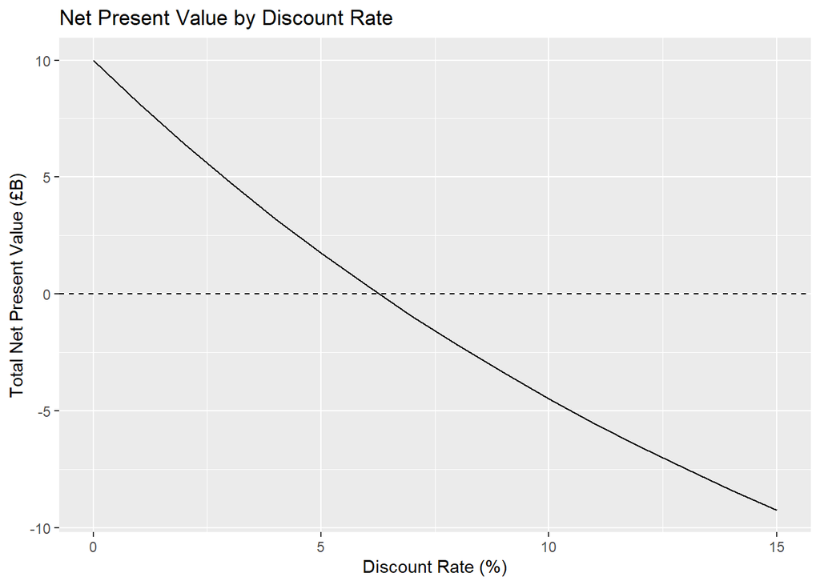

```r
rates <- seq(0, 0.15, by = 0.01)
npv_df <- npv_vs_rate(cashflows, rates)

ggplot(npv_df, aes(x = rate * 100, y = npv)) +
  geom_line() +
  geom_hline(yintercept = 0, linetype = "dashed") +
  labs(
    title = "Net Present Value by Discount Rate",
    x = "Discount Rate (%)",
    y = "Total Net Present Value (£B)"
  )
```

The **internal rate of return (IRR)** is the discount rate at which NPV is approximately zero.

```r
irr_index <- which.min(abs(npv_df$npv))
irr_rate  <- npv_df$rate[irr_index]
irr_rate * 100
```

```
## [1] 6
```

At discount rates **lower** than the IRR, the NPV is positive and the investment is attractive. At rates **higher** than the IRR, the NPV is negative, suggesting that the required return is too high for this cashflow profile.

# 2. Linear Programming: Production Planning

This section models the production of ICE cars, EVs and hybrids as a linear programming problem and solves it using `lpSolve`.

## 2.1 ICE vs EV

Here I model only ICE and EV production, using your original constraints on semiconductors, production rate and minimum ICE contract.

```r
sol_2var <- solve_ice_ev()
sol_2var
```

```
## $status
## [1] 0
##
## $optimum
## [1] 1020000
##
## $ice
## [1] 180
##
## $ev
## [1] 660
```

The solution returns the optimal daily quantities of ICE cars and EVs, together with the maximum daily profit achievable under the constraints.

## 2.2 ICE, EV and Hybrid vehicles

Next I extend the model to include hybrid vehicles and reuse the same constraints, with the semiconductor limit as a parameter.

### Baseline: 1,500 semiconductor boxes per day

```r
sol_3var_1500 <- solve_ice_ev_hybrid(semiconductor_limit = 1500)
sol_3var_1500
```

```
## $status
## [1] 0
##
## $optimum
## [1] 1050000
##
## $ice
## [1] 100
##
## $ev
## [1] 600
##
## $hybrid
## [1] 100
```

### Increased supply: 3,000 semiconductor boxes per day

```r
sol_3var_3000 <- solve_ice_ev_hybrid(semiconductor_limit = 3000)
sol_3var_3000
```

```
## $status
## [1] 0
##
## $optimum
## [1] 1100000
##
## $ice
## [1] 100
##
## $ev
## [1] 900
##
## $hybrid
## [1] 0
```

Comparing these solutions shows how the optimal production mix and profit change as the semiconductor constraint is relaxed. The model makes it clear which vehicle type scales most profitably when the bottleneck resource is expanded.

# 3. Electric Vehicle Dataset: Exploratory Analysis

In this section I work with an anonymised EV dataset. It contains technical and pricing information for around 200 electric vehicles.

## 3.1 Load and inspect the data

```r
ev <- load_ev_data()
dim(ev)
```

```
## [1] 198  11
```

```r
head(ev)
```

```
## # A tibble: 6 × 11
##   CarID  ...2      Battery To100sec TopSpeed Range WhperKm FastChargeSpeed Drive
##   <chr>  <chr>       <dbl>    <dbl>    <dbl> <dbl>   <dbl>           <dbl> <dbl>
## 1 EV_001 Abarth 5…    37.3      7        155   225     166             370     0
## 2 EV_002 Audi Q4 …    76.6      8.5      160   425     180             540     1
## 3 EV_003 Audi Q4 …    76.6      6.2      180   400     192             500     2
## 4 EV_004 Audi Q4 …    76.6      8.5      160   405     189             510     1
## 5 EV_005 Audi Q4 …    76.6      6.2      180   385     199             490     2
## 6 EV_006 Audi Q8 …    89        6        200   415     214             580     2
## # ℹ 2 more variables: NumberofSeats <dbl>, Price <dbl>
```

The dataset includes battery size, range, top speed, efficiency and price, among other attributes.

## 3.2 Key relationships

### Range vs battery size

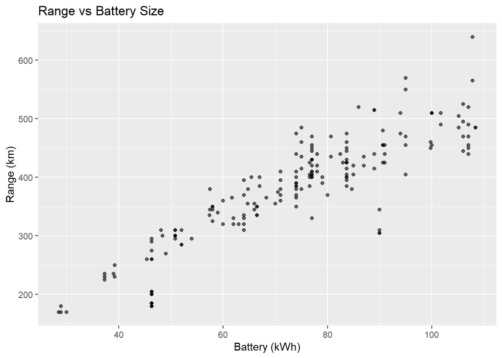

```r
ggplot(ev, aes(x = Battery, y = Range)) +
  geom_point(alpha = 0.6) +
  labs(
    title = "Range vs Battery Size",
    x = "Battery (kWh)",
    y = "Range (km)"
  )
```

### Price vs top speed

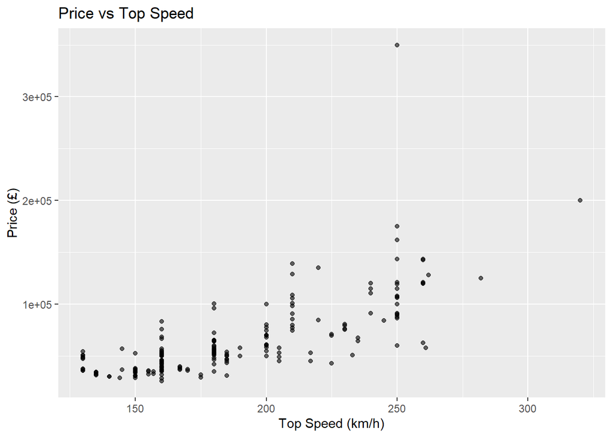

```r
ggplot(ev, aes(x = TopSpeed, y = Price)) +
  geom_point(alpha = 0.6) +
  labs(
    title = "Price vs Top Speed",
    x = "Top Speed (km/h)",
    y = "Price (£)"
  )
```

### Charge speed vs battery size

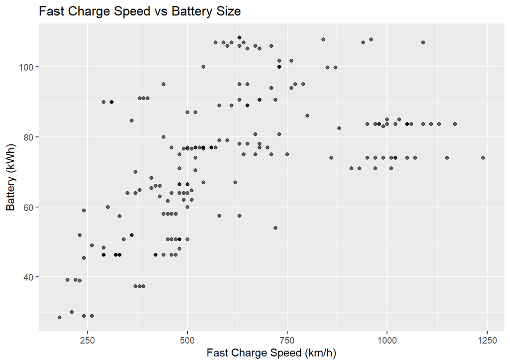

```r
ggplot(ev, aes(x = FastChargeSpeed, y = Battery)) +
  geom_point(alpha = 0.6) +
  labs(
    title = "Fast Charge Speed vs Battery Size",
    x = "Fast Charge Speed (km/h)",
    y = "Battery (kWh)"
  )
```

Together, these plots highlight how range tends to scale with battery size, how performance relates to price, and how charging characteristics vary across the fleet.

## 3.3 “Which car is…?” queries

```r
ev_stats <- ev_summary_stats(ev)

ev_stats$max_range        # maximum range
```

```
## # A tibble: 1 × 11
##   CarID  ...2      Battery To100sec TopSpeed Range WhperKm FastChargeSpeed Drive
##   <chr>  <chr>       <dbl>    <dbl>    <dbl> <dbl>   <dbl>           <dbl> <dbl>
## 1 EV_096 Mercedes…    108.      6.2      210   640     168             960     1
## # ℹ 2 more variables: NumberofSeats <dbl>, Price <dbl>
```

```r
ev_stats$most_efficient   # minimum Wh per km
```

```
## # A tibble: 1 × 11
##   CarID  ...2      Battery To100sec TopSpeed Range WhperKm FastChargeSpeed Drive
##   <chr>  <chr>       <dbl>    <dbl>    <dbl> <dbl>   <dbl>           <dbl> <dbl>
## 1 EV_168 Tesla Mo…    57.5      6.1      225   380     151             630     1
## # ℹ 2 more variables: NumberofSeats <dbl>, Price <dbl>
```

```r
ev_stats$fastest          # highest top speed
```

```
## # A tibble: 1 × 11
##   CarID  ...2      Battery To100sec TopSpeed Range WhperKm FastChargeSpeed Drive
##   <chr>  <chr>       <dbl>    <dbl>    <dbl> <dbl>   <dbl>           <dbl> <dbl>
## 1 EV_080 Maserati…      83      2.7      320   425     195             990     2
## # ℹ 2 more variables: NumberofSeats <dbl>, Price <dbl>
```

```r
ev_stats$fastest_accel    # lowest 0–100 time
```

```
## # A tibble: 1 × 11
##   CarID  ...2      Battery To100sec TopSpeed Range WhperKm FastChargeSpeed Drive
##   <chr>  <chr>       <dbl>    <dbl>    <dbl> <dbl>   <dbl>           <dbl> <dbl>
## 1 EV_172 Tesla Mo…      95      2.1      282   550     173             770     2
## # ℹ 2 more variables: NumberofSeats <dbl>, Price <dbl>
```

```r
ev_stats$cheapest         # lowest price
```

```
## # A tibble: 1 × 11
##   CarID  ...2      Battery To100sec TopSpeed Range WhperKm FastChargeSpeed Drive
##   <chr>  <chr>       <dbl>    <dbl>    <dbl> <dbl>   <dbl>           <dbl> <dbl>
## 1 EV_075 MG MG4 E…    50.8      7.7      160   300     169             340     1
## # ℹ 2 more variables: NumberofSeats <dbl>, Price <dbl>
```

These queries reproduce the kind of targeted questions often asked in exploratory phases: identifying extremes, best performers and budget options within the dataset.

# 4. Cryptocurrency Candles: Prices and Log-Returns

The final section works with an anonymised daily OHLC cryptocurrency dataset and constructs:

- a **prices matrix** with one column per trading pair, and
- the corresponding **log-returns**.

## 4.1 Load data and build prices table

```r
candles <- load_crypto()
head(candles)
```

```
## # A tibble: 6 × 7
##   TIMESTAMP   OPEN CLOSE  HIGH   LOW VOLUME SYMBOL
##   <date>     <dbl> <dbl> <dbl> <dbl>  <dbl> <chr>
## 1 2023-10-07 0.258 0.256 0.258 0.255 10097. PAIR_001
## 2 2023-10-06 0.250 0.257 0.258 0.250 12119. PAIR_001
## 3 2023-10-05 0.256 0.251 0.256 0.250 15890. PAIR_001
## 4 2023-10-04 0.258 0.256 0.258 0.250 10378. PAIR_001
## 5 2023-10-03 0.269 0.259 0.271 0.259 13890. PAIR_001
## 6 2023-10-02 0.277 0.268 0.282 0.264 18756. PAIR_001
```

```r
prices <- build_prices_matrix(candles)
dim(prices)
```

```
## [1] 1741  405
```

```r
head(prices[, 1:3])
```

```
##            PAIR_001 PAIR_002 PAIR_003
## 2019-01-01       NA       NA       NA
## 2019-01-02       NA       NA       NA
## 2019-01-03       NA       NA       NA
## 2019-01-04       NA       NA       NA
## 2019-01-05       NA       NA       NA
## 2019-01-06       NA       NA       NA
```

Each column in `prices` corresponds to a trading pair; each row corresponds to a calendar date.

## 4.2 Clean missing values and compute log-returns

```r
log_returns <- clean_and_log_returns(prices)
dim(log_returns)
```

```
## [1] 1740  405
```

```r
head(log_returns[, 1:3])
```

```
##            PAIR_001 PAIR_002 PAIR_003
## 2019-01-02        0        0        0
## 2019-01-03        0        0        0
## 2019-01-04        0        0        0
## 2019-01-05        0        0        0
## 2019-01-06        0        0        0
## 2019-01-07        0        0        0
```

Log-returns express day-to-day percentage changes in log scale and are typically preferred for time-series modelling of financial assets.

## 4.3 Example plots for selected pairs

Here I plot prices and log-returns for three anonymised pairs.

```r
pair_names <- colnames(prices)[1:3]

par(mfrow = c(3, 2), mar = c(3, 4, 2, 1))

for (p in pair_names) {
  plot(prices[, p],
       main = paste("Price -", p),
       xlab = "Date", ylab = "Close")

  plot(log_returns[, p],
       main = paste("Log returns -", p),
       xlab = "Date", ylab = "Log return")
}

par(mfrow = c(1, 1))
```

[output not shown]